# New Republic Elementary Dashboard Summary

## Report Purpose

This report is created to assist New Republic Elementary in reflecting on their student groups and how they relate to DA, CSI, ATSI and TSI.

## Qualifying Groups

Differentiated Assistance is determined by the California Dashboard. Colors reflect the latest available status from 2024.

The graphic below shows the color for each student group for each indicator for Santa Rita Union Elementary from the [California Dashboard 2024](https://www.caschooldashboard.org/reports/27661910000000/2024)

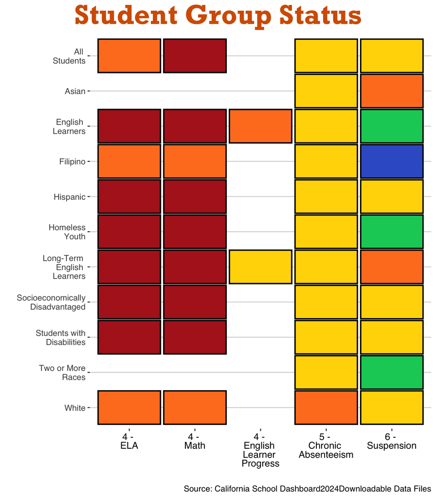

The graphic below shows the color for each student group for each indicator for New Republic Elementary from the [California Dashboard 2024](https://www.caschooldashboard.org/reports/27661910107391/2024) The school level results contributed to Santa Rita Union Elementary overall.

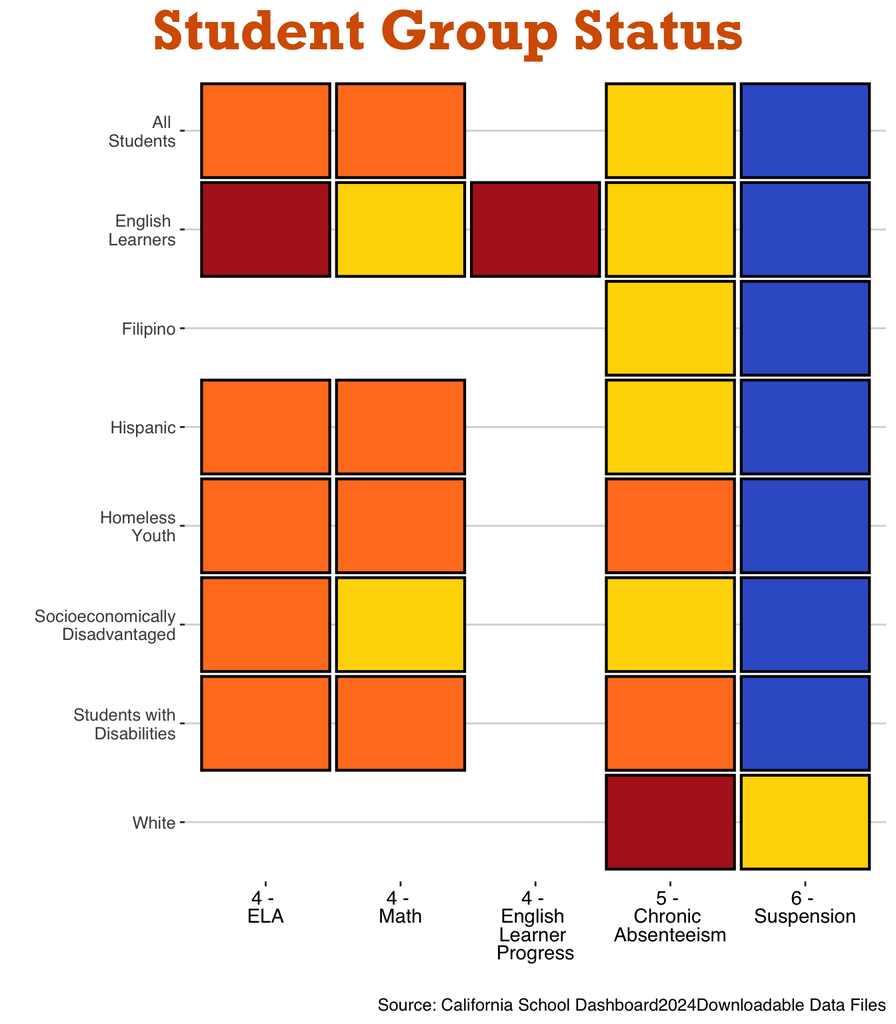

## CSI/ATSI/TSI Designations

Under ESSA, every third year schools can be identified for Comprehensive Support and Improvement (CSI) or Additional Targeted Support and Improvement (ATSI). In the other years schools can be identified for Targeted Support and Improvement (TSI). CSI is based on a school’s overall or All Students indicators, whereas ATSI and TSI are based on each student group’s indicators. For more information please see: [CDE School Support](https://www.cde.ca.gov/sp/sw/t1/schoolsupport.asp). It is important to note that calculations are only based on student groups with 30 or more students.

New Republic Elementary is eligible for TSI, WH students have been identified as meeting ATSI/TSI criteria.

## Status Details for all Indicators

These graphs represent all of the indicators from the Dashboard and show how each of the student groups performed.

**Click here to display graphs**

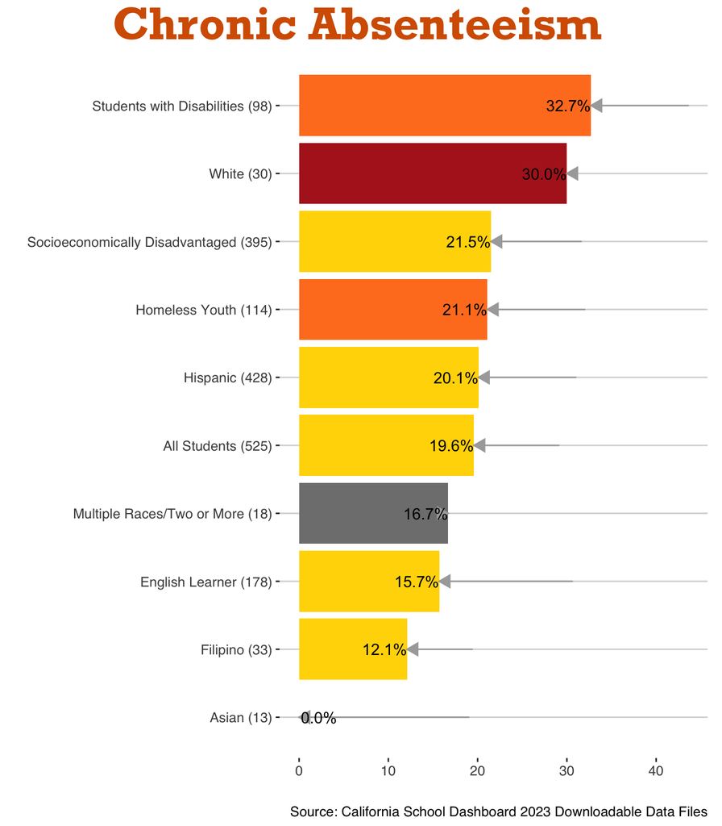

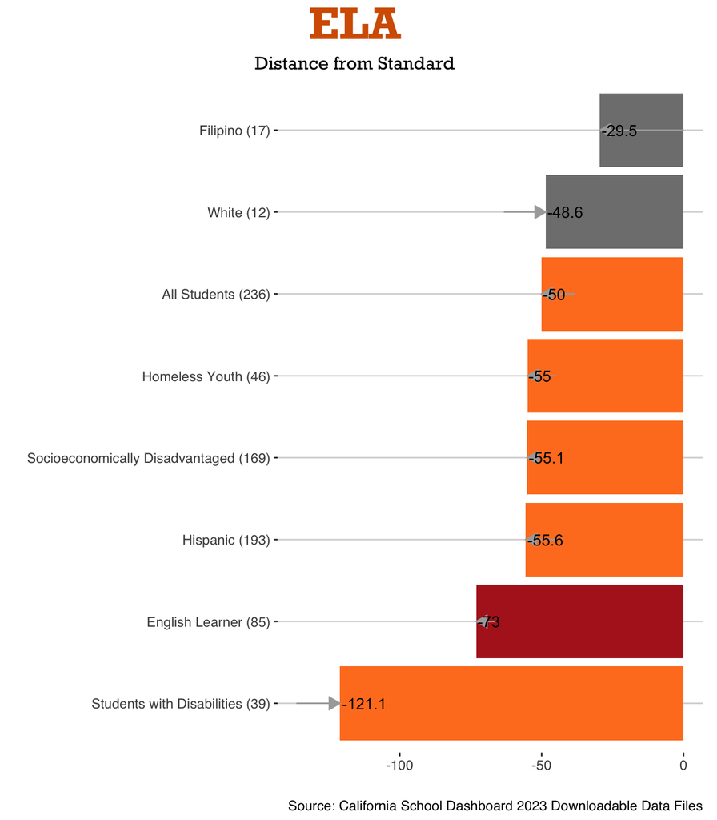

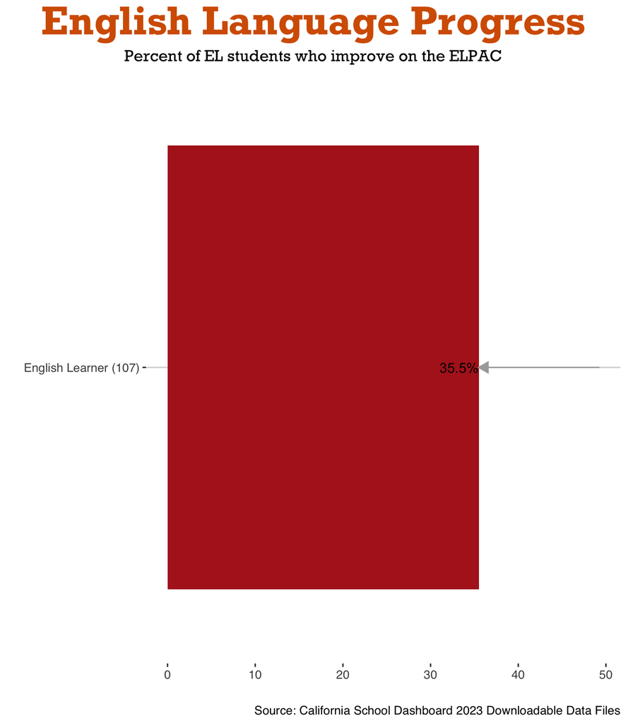

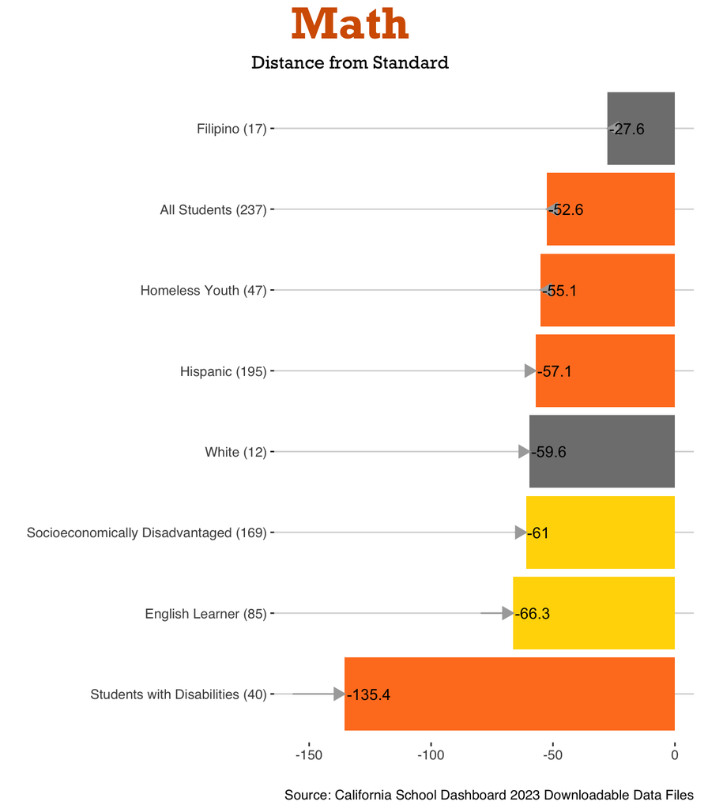

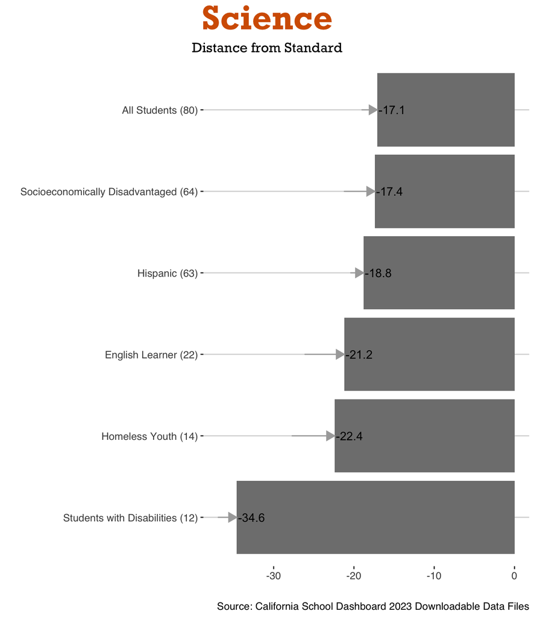

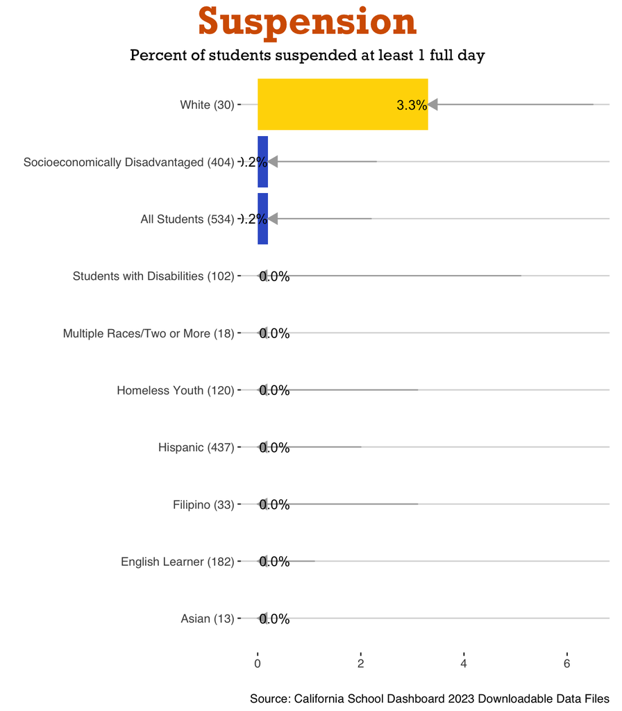

## Status Details for all Indicators Side-by-Side

These graphs represent all of the indicators from the Dashboard and show how each of the student groups performed in 2024 and 2023.

**Click here to display graphs**

[figure not shown]

[figure not shown]

[figure not shown]

[figure not shown]

[figure not shown]

[figure not shown]

## Historical Confetti

These graphs represent all of the indicators from Priority Areas that qualified the district. They included all qualifying subgroups on each graph, whether this was a qualifying indicator or not, as well as the All Students group for comparisons.

**Click here to display graphs**

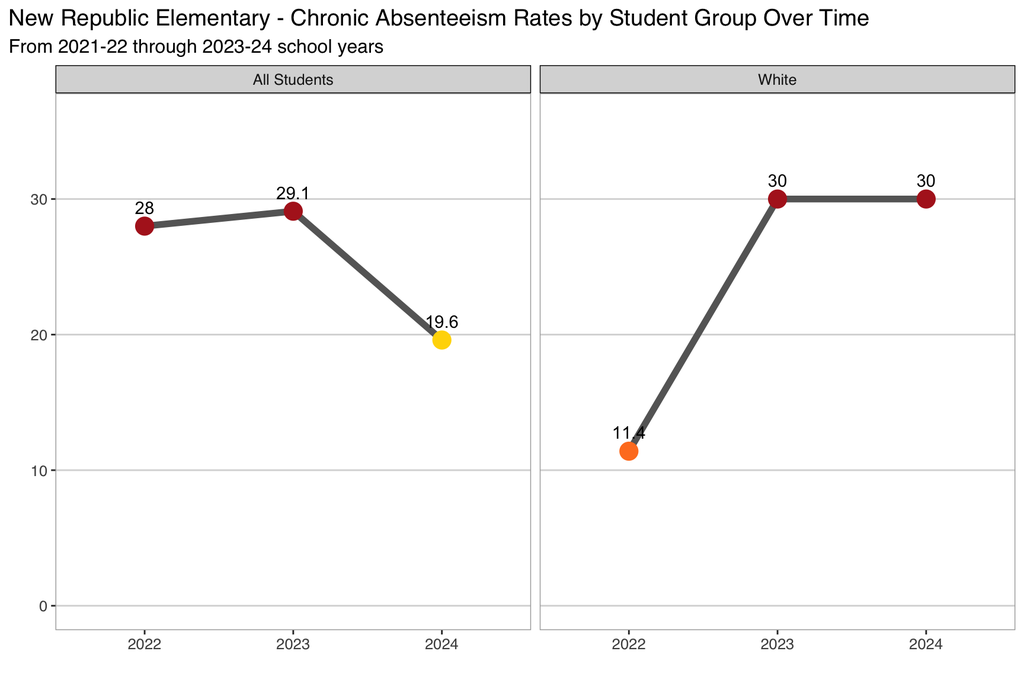

## Status Needed to Avoid Red in 2024

This section estimates the limits for indicators to receive an orange or higher color next year on the 2024 Dashboard. The thresholds below are based on the [5x5 grids last approved by the State Board of Education](https://www.cde.ca.gov/ta/ac/cm/fivebyfivecolortables19.asp#AcademicTable) and the number of students in the 2023 calculation. State policies may change and the student counts may shift. Only student groups in DA and their qualifying indicators for Santa Rita Union Elementary are included below and only if they are in the lowest status for New Republic Elementary. The thresholds represent the numbers for New Republic Elementary.

| Student Group | Indicator | Current Status | Target Status for Orange | Change Needed | Number of Students (as applicable) |
| --- | --- | --- | --- | --- | --- |
| White | CHRO | 30 | 29.5 | -0.5 | 8 |
| English Learner | ELA | -73 | -70 | 3 |  |
| English Learner | ELPI | 35.5 | 35 | -0.5 | 38 |

**Click here to display sentences**

This report was last updated at 2025-01-03 08:30:30.521391.

It was developed by [David Dobrowski](https://github.com/dobrowski) at the [Monterey County Office of Education](https://www.montereycoe.org/)